# One Variable: Quantitative

Author

Orville D. Hombrebueno

Published

December 4, 2024

# The Data

```r
# install packages: install.packages("package")
# load packages
library(tidyverse)
library(knitr)
library(gtsummary)
library(ggstatsplot)
library(downlit)
library(broom)

# load data
data(iris)
```

## Edgar Anderson’s Iris Data

This famous (Fisher’s or Anderson’s) [iris](https://onlinelibrary.wiley.com/doi/10.1111/j.1469-1809.1936.tb02137.x) data set gives the measurements in centimeters of the variables sepal length and width and petal length and width, respectively, for 50 flowers from each of 3 species of iris. The species are Iris setosa, versicolor, and virginica.

The first 6 rows of the iris data set are shown in Table 1.

```r
iris |> # call the data
  head() |> # get the first six rows of the data
  kable( # create a table
    col.names = c( # change the column names
      "Sepal Length",
      "Sepal Width",
      "Petal Length",
      "Petal Width",
      "Species"
    )
  )
```

Table 1: The first 6 observations of the data set.

| Sepal Length | Sepal Width | Petal Length | Petal Width | Species |
| --- | --- | --- | --- | --- |
| 5.1 | 3.5 | 1.4 | 0.2 | setosa |
| 4.9 | 3.0 | 1.4 | 0.2 | setosa |
| 4.7 | 3.2 | 1.3 | 0.2 | setosa |
| 4.6 | 3.1 | 1.5 | 0.2 | setosa |
| 5.0 | 3.6 | 1.4 | 0.2 | setosa |
| 5.4 | 3.9 | 1.7 | 0.4 | setosa |

## Descriptive Statistics

```r
iris |> # call the data
  tbl_summary( # create a table
    include = c(Sepal.Length, Sepal.Width, Petal.Length, Petal.Width, Species), # select variables
    statistic = all_continuous() ~ "{mean} ± {sd} ({min} - {max})", # descriptive statistics
    digits = all_continuous() ~ 2, # no. of digits (rounding)
    label = list( # variable names
      Sepal.Length ~ "Sepal Length",
      Sepal.Width ~ "Sepal Width",
      Petal.Length ~ "Petal Length",
      Petal.Width ~ "Petal Width"
    )
  )
```

Table 2: Summary statistics of the data set.

| **Characteristic** | **N = 150**<sup>1</sup> |
| --- | --- |
| Sepal Length | 5.84 ± 0.83 (4.30 - 7.90) |
| Sepal Width | 3.06 ± 0.44 (2.00 - 4.40) |
| Petal Length | 3.76 ± 1.77 (1.00 - 6.90) |
| Petal Width | 1.20 ± 0.76 (0.10 - 2.50) |
| Species |  |
| setosa | 50 (33%) |
| versicolor | 50 (33%) |
| virginica | 50 (33%) |

<sup>1</sup> Mean ± SD (Min - Max); n (%)

A visualization of the sepal length is shown in Figure 1.

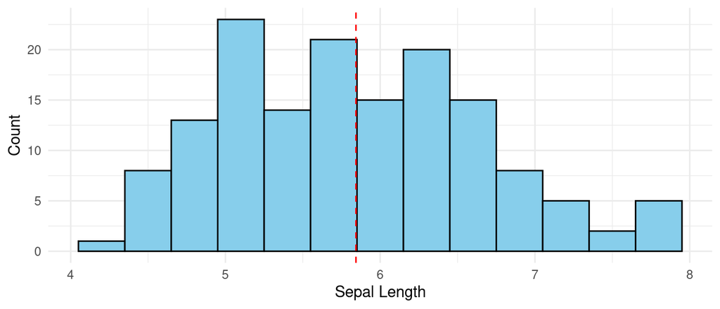

Figure 1: Histogram with mean line.

```r
mean_value <- mean(iris$Sepal.Length) # computed the mean sepal length of iris

iris |> # called the data
  ggplot(aes(x = Sepal.Length)) + # defining x y variables
  geom_histogram(binwidth = .3, fill = "skyblue", color = "black") +
  geom_vline(aes(xintercept = mean_value), color = "red", linetype = "dashed") +
  labs(x = "Sepal Length", y = "Count") +
  theme_minimal()
```

# Hypothesis Testing

**Two-Sided**

### Research Question

1. Is the mean sepal length different from the expected average of 5.8 cm?

### Results and Interpretation

The histogram and test statistics is shown on Figure 2.

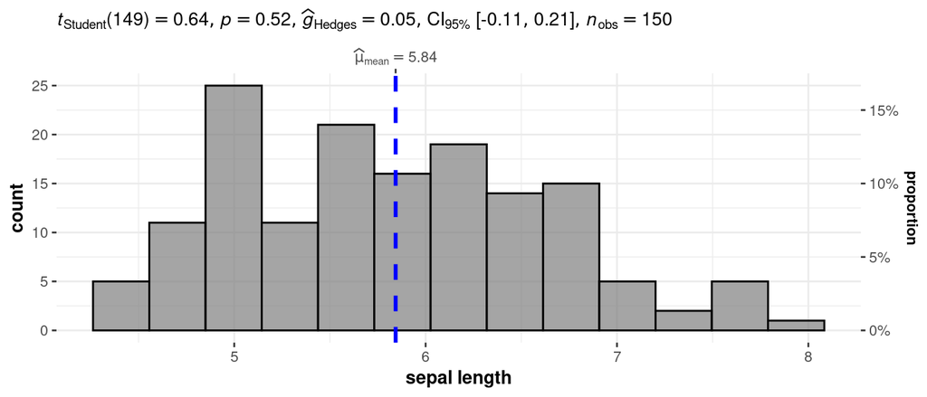

Figure 2: Histogram and test statistics.

```r
gghistostats( # create figure
  data = iris, # the data
  x = Sepal.Length, # variable of interest
  type = "parametric", # for student's t-test
  test.value = 5.8, # default value is 0
  xlab = "sepal length" # label of x-axis
) +
  labs(caption = NULL) # remove caption
```

Based on the histogram and the *p*-value being greater than 5% (*p*-value = 0.52), we do not reject the null hypothesis. There is no sufficient evidence that the mean sepal length is different from 5.8 cm.

**One-Sided**

### Research Question

Is the mean sepal length greater than the expected average of 5.7 cm?

### Hypothesis and Test Statistics

- $H_0:\mu=5.7$; the mean sepal length is equal to 5.7 cm.
- $H_a:\mu>5.7$; the mean sepal length is greater than 5.7 cm.
- Significance level, $\alpha=5\%$.
- **one sample t-test**
- The variance is unknown.
- $n>30$; large sample.

### Results and Interpretation

The test statistics is shown in Table 3.

```r
t.test(
  iris$Sepal.Length, # selecting sepal length
  mu = 5.7, # hypothesized value of the mean in the population
  alternative = "greater" # other options: "two.sided" or "less"
) |>
  tidy() |>
  select(estimate, statistic, p.value, method, alternative) |>
  mutate(across(where(is.numeric), ~ round(.x, 2))) |>
  kable()
```

Table 3: Test statistics.

| estimate | statistic | p.value | method | alternative |
| --- | --- | --- | --- | --- |
| 5.84 | 2.12 | 0.02 | One Sample t-test | greater |

Based on the results and the *p*-value being lesser than 5% (*p*-value = 0.02), we reject the null hypothesis. There is sufficient evidence that the mean sepal length is greater than the expected average of 5.7 cm.